# Rendimento real médio mensal de todos os trabalhos efetivos no Brasil

Doutorado em economia - Econometria II - Séries Temporais - Professor: Roberto Tatiwa - CAEN/UFC

Autor: Francisco Alexandre

2023-11-29

Email: [alecorreia94@alu.ufc.br]

GitHub: [https://github.com/alecorreia94/time-series-analysis-PNAD]

# 1 Introdução

A análise de séries temporais desempenha um papel crucial no campo da economia e na compreensão das tendências econômicas ao longo do tempo. Neste estudo, apresenta-se uma série temporal que representa o rendimento real médio mensal de todos os trabalhos efetivos no Brasil. Trata-se do rendimento bruto real médio efetivamente recebido no mês de referência em todos os trabalhos que as pessoas ocupadas com rendimento tinham na semana de referência.

Essa série reflete não apenas a situação econômica do país, mas também as condições de vida de seus habitantes. Os dados utilizados neste estudo foram obtidos por meio da biblioteca ipeatadar, disponibilizada pelo Instituto de Pesquisa Econômica Aplicada (IPEA).Desta forma,foram selecionadas informações da Pesquisa Nacional por Amostra de Domicílios Contínua (PNADC), Fonte confiável e abrangente de dados sobre o mercado de trabalho brasileiro.

Além disso, realiza-se uma análise mais profunda por meio de correlogramas para identificar possíveis modelos ARMA (AutoRegressive Moving Average) de forma a melhorar a compreensão sobre a estrutura temporal subjacente da série. Também aplica-se a técnica de dessazonalização X11 do Census Bureau dos Estados Unidos, para isolar a tendência e os componentes de erro da série, a fim de examiná-los com maior precisão.

Este estudo visa contribuir para uma melhor compreensão da dinâmica do mercado de trabalho no Brasil, permitindo uma análise mais informada das flutuações no rendimento real médio mensal de todos os trabalhos efetivos.

Na proxima seção, apresento os resultados desta análise, incluindo histograma da distribuição dos rendimentos, estatísticas descritivas que resumem as principais características da série temporal, correlogramas, estimação e testes sobre os modelos e por fim a previsão feita através do modelo selecionado pelos critérios estatisticos. Boa leitura!

```r
# Bibliotecas utilizadas no estudo:
library(knitr)
library(ipeadatar)
library(dplyr)
library(forecast)
library(dygraphs)
library(urca)
library(rugarch)
library(nortsTest)
```

```r
# Obtendo todas as séries disponíveis
series_ipeadata <- available_series()
```

```r
#Seleciona Rendimento real médio de todos os trabalhos efetivos mensais
#codigo: PNADC12_RRTE12
dados_RRTE <- ipeadata("PNADC12_RRTE12")
```

```r
# Selecione apenas as variáveis "data" e "valor" de dados_RRTE
dados_RRTE <- select(dados_RRTE, date, value)
```

# 2 Resultados

## 2.1 Histograma da distribuição dos dados de rendimento

Logo abaixo temos o histograma para melhor visualização da distribuição dos dados.

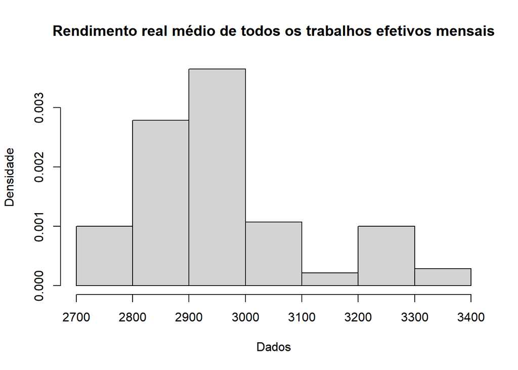

```r
#histograma
hist(dados_RRTE$value,prob=T,
     main="Rendimento real médio de todos os trabalhos efetivos mensais",
     ylab = "Densidade", xlab = "Dados")
```

Identifica-se pelo histograma da série de dados que a maioria dos resultados se concentram no intervalo de 2.800 a 3.000 reais em média.

## 2.2 Estatísticas Descritivas

```r
# Calcular estatísticas descritivas
estatisticas_RRTE <- dados_RRTE %>%
  summarise(
    Média = mean(value),
    Mediana = median(value),
    Mínimo = min(value),
    Máximo = max(value),
    Desvio_Padrão = sd(value),
    Variância = var(value)
  )

# Use a função kable para formatar a tabela
estatisticas_formatadas <- kable(estatisticas_RRTE,
                                 format = "markdown",
                                 col.names = c("Média", "Mediana", "Mínimo",
                                               "Máximo", "Desvio Padrão", "Variância"))

estatisticas_formatadas
```

| Média | Mediana | Mínimo | Máximo | Desvio Padrão | Variância |
| --- | --- | --- | --- | --- | --- |
| 2961.371 | 2932.5 | 2727 | 3364 | 145.1525 | 21069.24 |

## 2.3 Gráficos dá série

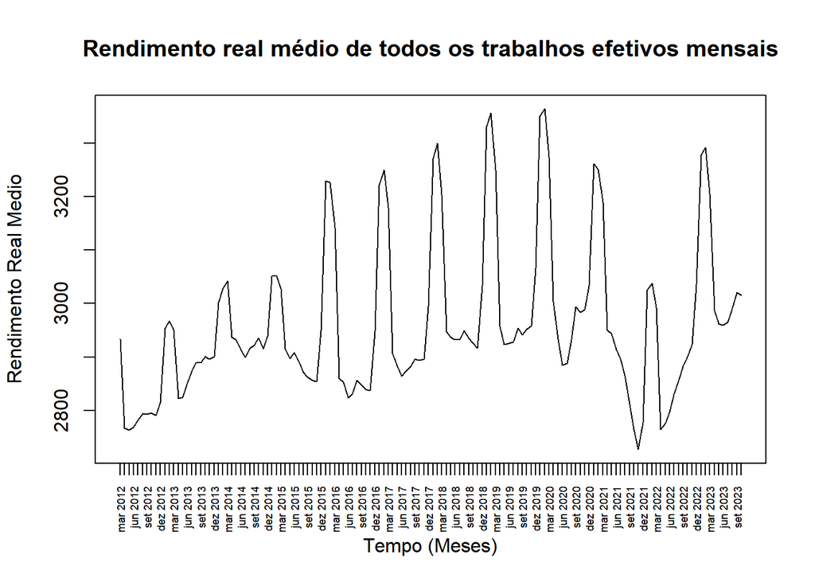

```r
# Cria um vetor de datas para o eixo x
datas <- seq(as.Date("2012-03-01"), as.Date("2023-10-01"), by = "1 month")

# Cria o gráfico de séries temporais
plot.ts(dados_RRTE$value,
        main = "Rendimento real médio de todos os trabalhos efetivos mensais",
        xaxt = "n", ylab = "Rendimento Real Medio", xlab = "Tempo (Meses)")

# Personalize o eixo x
axis(1, at = 1:length(datas), labels = format(datas, "%b %Y"),
     tick = TRUE, las = 2,cex.axis = 0.55)
```

Logo abaixo temos o mesmo gráfico apresentado com mais detalhes para melhor interação e visualização (Obs: este gráfico abaixo deve ser visto em formato .html)

```r
#Série
serie = ts(dados_RRTE$value, start = c(2012,3), frequency = 12)

#limpando possiveis outliers
tsclean.serie <- tsclean(serie)

#para html
# Gráfico dos dados com detalhes
dygraph(
  data = serie,
  main = "Rendimento Real Medio do Brasil de 2012 a 2023",
  xlab = "Meses",
  ylab = "Rendimento Real Medio"
)
```

[interactive chart not shown]

## 2.4 Teste de raiz unitária

```r
#Teste de raiz unitária com 5 lags, drift e criterios BIC
ur <- ur.df(y = serie, lags = 5, type = "drift", selectlags = "BIC")
ur@testreg
```

```
##
## Call:
## lm(formula = z.diff ~ z.lag.1 + 1 + z.diff.lag)
##
## Residuals:
##     Min      1Q  Median      3Q     Max
## -131.56  -44.94  -19.18   30.19  263.51
##
## Coefficients:
##               Estimate Std. Error t value Pr(>|t|)
## (Intercept) 1067.18132  200.53071   5.322 4.45e-07 ***
## z.lag.1       -0.35953    0.06763  -5.317 4.56e-07 ***
## z.diff.lag1    0.57732    0.08782   6.574 1.13e-09 ***
## z.diff.lag2    0.12186    0.08370   1.456 0.147904
## z.diff.lag3   -0.31066    0.08192  -3.792 0.000229 ***
## z.diff.lag4    0.27807    0.08369   3.323 0.001163 **
## ---
## Signif. codes:  0 '***' 0.001 '**' 0.01 '*' 0.05 '.' 0.1 ' ' 1
##
## Residual standard error: 75.57 on 128 degrees of freedom
## Multiple R-squared:  0.4634, Adjusted R-squared:  0.4424
## F-statistic:  22.1 on 5 and 128 DF,  p-value: 6.432e-16
```

```r
ur@cval
```

```
##       1pct  5pct 10pct
## tau2 -3.46 -2.88 -2.57
## phi1  6.52  4.63  3.81
```

O modelo foi selecionado com 4 lags, mesmo sendo fornecido 5 lags. Analisando os resultados encontra-se o coeficiente $z.lag.1$, parâmetro de interesse para o teste de raiz unitária e para avaliar a sua significância precisa-se da tabela de valores críticos que fica na variável $ur@cval$ do teste.

## 2.5 Correlogramas e modelos ARMA(p,q)

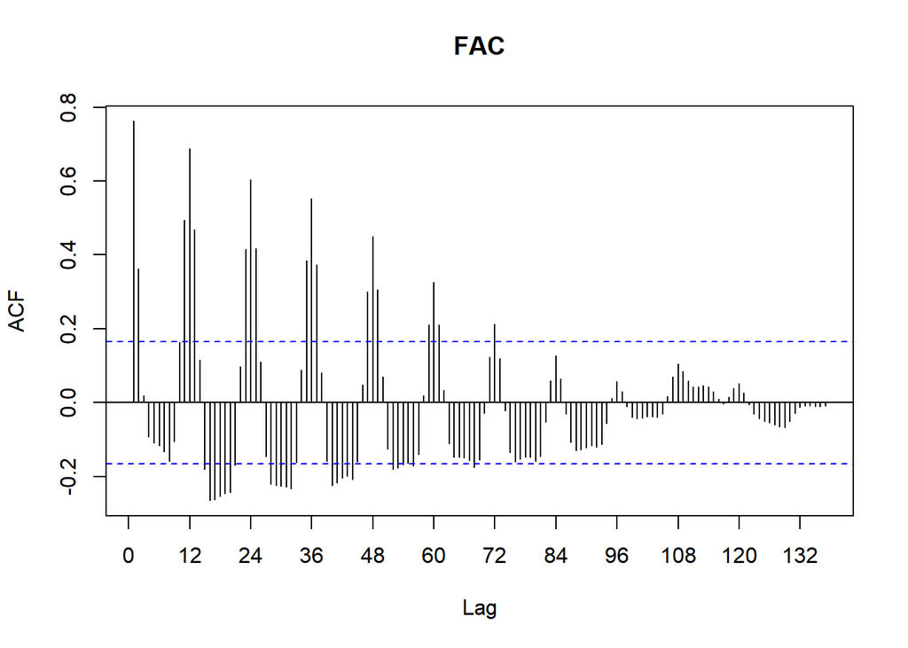

```r
#FAC E FACP da serie refet
Acf(serie,lag=137,main="FAC" )
```

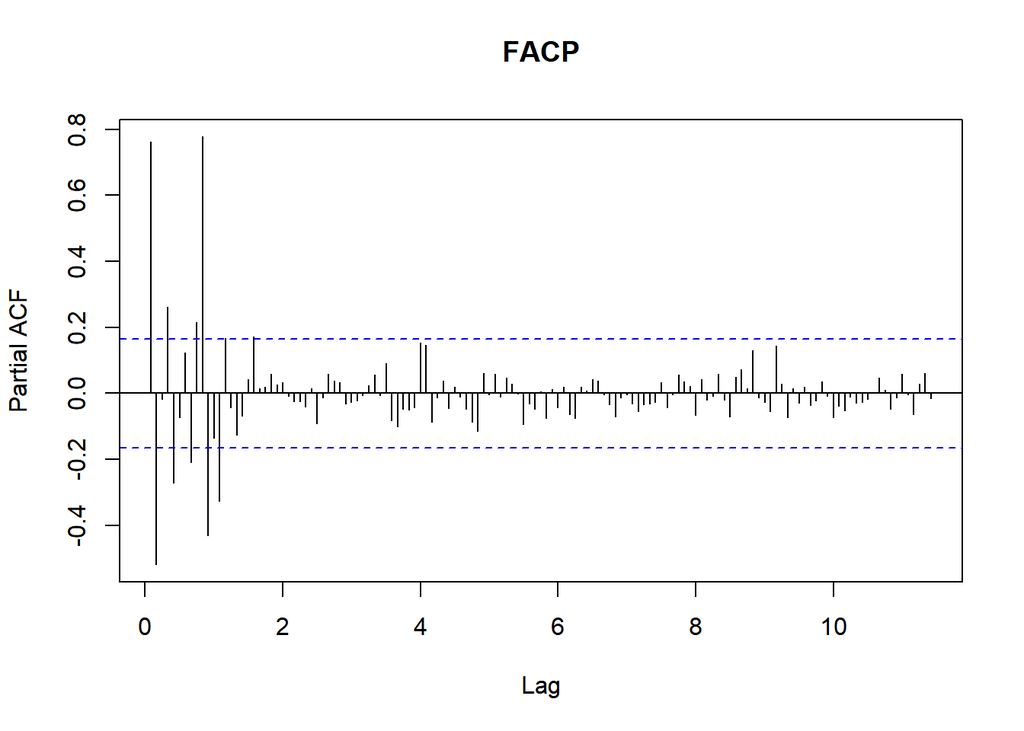

```r
pacf(serie,lag=137,main="FACP")
```

Ao observar o correlograma, percebe-se uma sazonalidade do tipo multiplicativa que incide em épocas específicas e em seus arredores. Isto é, a significância estatística não se limita apenas aos períodos, mas também abrange os arredores da série de dados. Considerando essa análise, pondera-se sobre alguns modelos do tipo ARMA que podem ser apropriados. O AR(2) surge como uma escolha adequada, uma vez que na Função de Autocorrelação (FAC), há um declínio exponencial visível, enquanto na Função de Autocorrelação Parcial (FACP), ocorre um truncamento no segundo lag. Também é possível sugerir a possibilidade de um MA(2), uma vez que existe um truncamento no segundo lag da FAC. Dessa forma, pretende-se testar um modelo do tipo ARMA(2,2), AR(2) e MA(2) para uma análise mais profunda presente nos dados é aconselhável verificar todas as combinações possíveis de um ARMA(2,2). Mas antes devemos dessazonalizar a série.

## 2.6 Decomposição X11

Ao perceber a sazonalidade um método comum para dessazonalizar séries temporais é utilizar a metodologia do Census Bureau dos Estados Unidos da América, conhecida como X11 (US BUREAU OF THE CENSUS, 2013). O primeiro passo é carregar o pacote ‘seasonal’ (SAX e EDDELBUETTEL, 2018) no ambiente de trabalho. Para visualizar os resultados, utilizei a função ‘autoplot’ do pacote ‘fpp2’ (HYNDMAN, 2018), que nos permite criar um gráfico informativo.

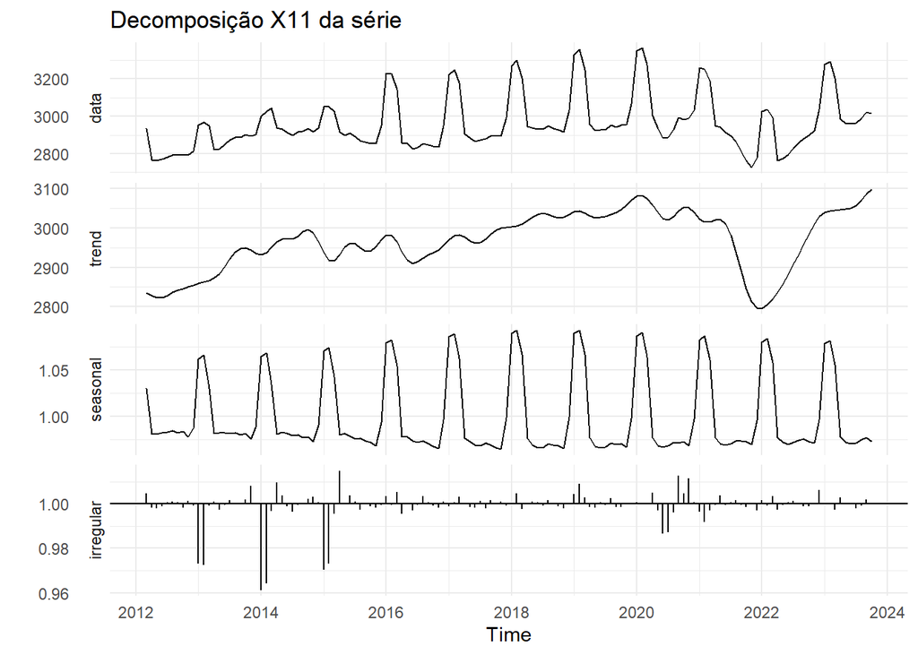

```r
serie = ts(dados_RRTE$value, start = c(2012,3), frequency = 12)

# decomposicao pelo X11 do Census Bureau
library(seasonal)
fit <- seas(serie, x11 = "")
# uso a serie 'serie', aplico o 'seas' x11
# e gero 'fit'

library(fpp2)
autoplot(fit) + ggtitle("Decomposição X11 da série")+theme_minimal()
```

## 2.7 Gráfico da série dessazonalizada

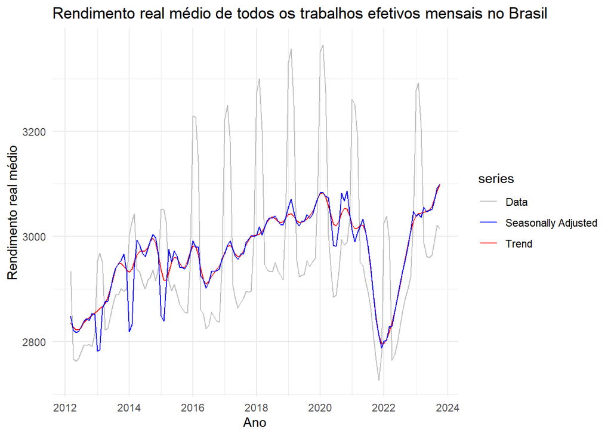

```r
autoplot(serie, series = "Data") + autolayer(trendcycle(fit),
                                             series = "Trend") + theme_minimal()+
    autolayer(seasadj(fit),
series = "Seasonally Adjusted") + xlab("Ano") + ylab("Rendimento real médio") +
ggtitle("Rendimento real médio de todos os trabalhos efetivos mensais no Brasil") +
scale_colour_manual(values = c("gray", "blue", "red"), breaks = c("Data",
                                                                  "Seasonally Adjusted",
                                                                  "Trend"))
```

Observa-se na série temporal a presença de componentes sazonais. Para isolar esses elementos, foi realizada a decomposição da série, resultando na extração da componente dessazonalizada. Em outras palavras, a série dessazonalizada consiste apenas na parte que reflete a tendência e os componentes de erro, eliminando completamente a influência sazonal. Portanto, agora dispomos da série temporal original, porém, sem a presença da sazonalidade, o que nos permite analisá-la de forma mais precisa e identificar padrões e correlações sem a interferência das variações sazonais.

Baseado no correlograma da série estima-se abaixo os modelos ARMA adequados

## 2.8 Tabela dos modelos ARMA(p,q)

```r
# Lista de ordens ARMA a serem testadas
ordens <- expand.grid(p = 0:2, q = 0:2)

# Função para ajustar modelo ARMA e calcular AIC e BIC
ajustar_modelo_arma <- function(p, q) {
  modelo <- Arima(seasadj(fit), order = c(p, 0, q))
  return(c(especificacao = paste0("ARMA(", p, ",", q, ")"),
           ln_verossimilhanca = round(logLik(modelo), digits = 3),
           qtd_parametros = length(coef(modelo)),
           tamanho_amostra = length(serie),
           AIC = round(AIC(modelo), digits = 2),
           BIC = round(BIC(modelo), digits = 2)))
}
# Aplicar a função para cada ordem ARMA
resultados <- apply(ordens, 1, function(row) ajustar_modelo_arma(row[1], row[2]))

# Converter a matriz de resultados em um dataframe
resultados_df <- as.data.frame(t(resultados))

# Exibir os resultados
# Usando a função kable para criar a tabela
tabela_markdown <- kable(resultados_df, format = "markdown", align = "c")
tabela_markdown
```

| especificacao | ln_verossimilhanca | qtd_parametros | tamanho_amostra | AIC | BIC |
| --- | --- | --- | --- | --- | --- |
| ARMA(0,0) | -812.164 | 1 | 140 | 1628.33 | 1634.21 |
| ARMA(1,0) | -667.389 | 2 | 140 | 1340.78 | 1349.6 |
| ARMA(2,0) | -656.42 | 3 | 140 | 1320.84 | 1332.61 |
| ARMA(0,1) | -739.334 | 2 | 140 | 1484.67 | 1493.49 |
| ARMA(1,1) | -654.443 | 3 | 140 | 1316.89 | 1328.65 |
| ARMA(2,1) | -653.912 | 4 | 140 | 1317.82 | 1332.53 |
| ARMA(0,2) | -687.147 | 3 | 140 | 1382.29 | 1394.06 |
| ARMA(1,2) | -653.107 | 4 | 140 | 1316.21 | 1330.92 |
| ARMA(2,2) | -650.268 | 5 | 140 | 1312.54 | 1330.18 |

```r
# Estima o modelo ARMA(2,2)
modelo_arma_22 <- Arima(seasadj(fit), order = c(2, 0, 2))
summary(modelo_arma_22)
```

```
## Series: seasadj(fit)
## ARIMA(2,0,2) with non-zero mean
##
## Coefficients:
##          ar1     ar2     ma1     ma2       mean
##       0.2374  0.5448  1.2313  0.5496  2965.5935
## s.e.  0.1348  0.1260  0.1307  0.1007    25.6459
##
## sigma^2 = 643.6:  log likelihood = -650.27
## AIC=1312.54   AICc=1313.17   BIC=1330.18
##
## Training set error measures:
##                     ME     RMSE      MAE        MPE      MAPE      MASE
## Training set 0.6691443 24.91273 18.12586 0.01537902 0.6166214 0.2556751
##                     ACF1
## Training set -0.03778891
```

```r
# Coletar informações do modelo ARIMA(2,0,2)
coef_arma_22 <- coef(modelo_arma_22)
desv_p_arma_22 <- sqrt(diag(vcov(modelo_arma_22)))
t_val_arma_22 <- coef_arma_22 / desv_p_arma_22

# Criar uma tabela com os valores dos coeficientes, desvios padrões e valores
# t (excluindo o intercepto)
tabela_coef_desv_t <- data.frame(Valor_Coeficiente =coef_arma_22[-5],
                                            Desv_P = desv_p_arma_22[-5],
                                            Valor_t = t_val_arma_22[-5])
# Usando a função kable para criar a tabela
tabela_markdown <- kable(tabela_coef_desv_t, format = "markdown", align = "c")
tabela_markdown
```

|  | Valor_Coeficiente | Desv_P | Valor_t |
| --- | --- | --- | --- |
| ar1 | 0.2373966 | 0.1347720 | 1.761468 |
| ar2 | 0.5447691 | 0.1260155 | 4.323032 |
| ma1 | 1.2313085 | 0.1306623 | 9.423592 |
| ma2 | 0.5495667 | 0.1006649 | 5.459366 |

Pela tabela acima podemos ver que no AR(1) possui o único valor t que não ultrapassa 1.96, isto é, para um nível de significância de 5% mostra não ser um parâmetro com significancia estatistica. Dessa Forma, Fica mais claro que nosso modelo preferivel seja o ARMA(2,2). Cabe destacar que essa estimação foi feita retirando a sazonalidade dos dados, ao deixar o efeito de sazonalidade o AR(2) é que se torna não significante. Por fim, como último teste observa-se o correlograma dos resíduos a fim de identificar indícios de normalidade.

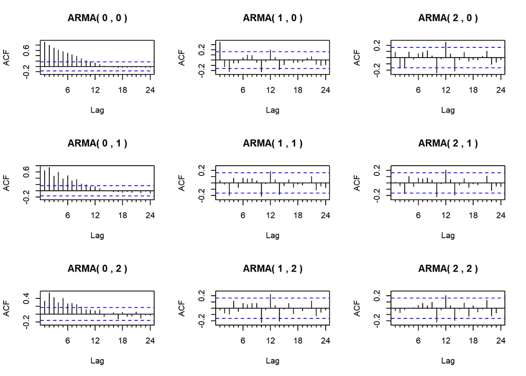

```r
# Lista de ordens ARMA(2,2)
ordens <- expand.grid(p = 0:2, q = 0:2)

# Configurar o layout para 3x3 (ou o número desejado)
par(mfrow = c(3, 3))

# Loop para ajustar modelos e criar correlogramas
for (i in 1:nrow(ordens)) {
  p <- ordens$p[i]
  q <- ordens$q[i]

  # Ajustar modelo ARMA
  modelo <- Arima(seasadj(fit), order = c(p, 0, q))
  residuos <- residuals(modelo)

  # Criar correlograma dos resíduos
  modelo_nome <- paste("ARMA(", p, ",", q, ")")
  Acf(residuos, main = modelo_nome)
}
```

```r
# Restaurar a configuração padrão
par(mfrow = c(1, 1))
```

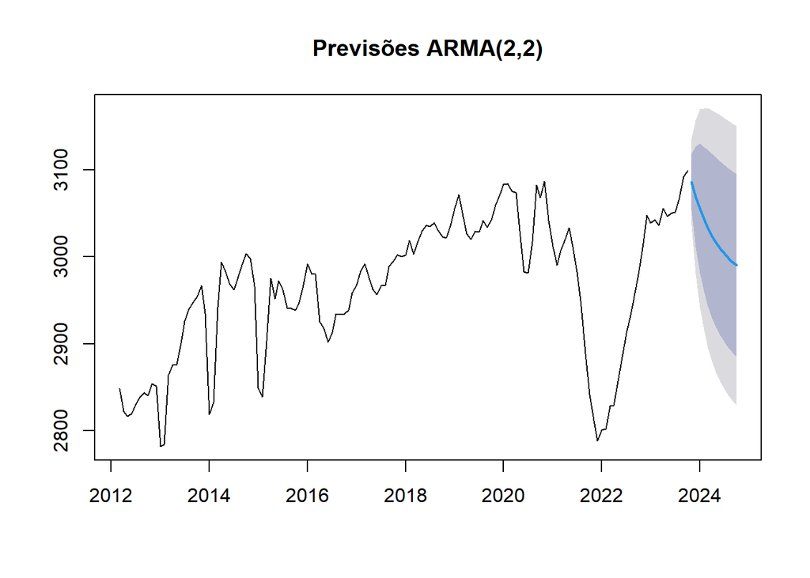

```r
# Gerar previsões
previsoes <- forecast(modelo_arma_22, h = 12)  # Ajuste h conforme necessário

# Plotar as previsões
plot(previsoes, main = "Previsões ARMA(2,2)")
```

Como ultima etapa de análise deste estudo mostramos os testes em relação a heterocedasticidade condicional do modelo escolhido.

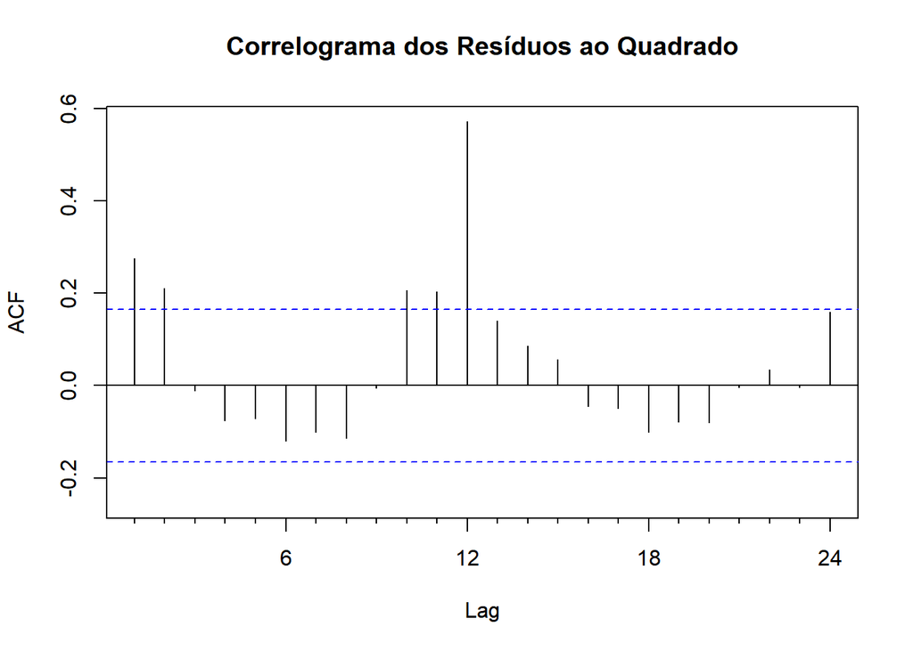

```r
# Calcular os resíduos ao quadrado
residuos_quadrados <- residuos^2

# Criar correlograma dos resíduos ao quadrado
Acf(residuos_quadrados, main = "Correlograma dos Resíduos ao Quadrado")
```

```r
#Teste Arch
arch.test(residuos_quadrados,arch = c("box","Lm"),alpha = 0.05,lag.max = 2)
```

```
##
##  Box-Ljung test
##
## data:  y^2
## X-squared = 1.8458, df = 2, p-value = 0.3974
## alternative hypothesis: y is heteroscedastic
```

```r
# Ajustar um modelo GARCH aos resíduos
modelo_garch <- ugarchspec(variance.model = list(model = "sGARCH",
                                                 garchOrder = c(1, 1)),
                           mean.model = list(armaOrder = c(2, 2)))
ajuste_garch <- ugarchfit(modelo_garch, data = residuos_quadrados)

print(ajuste_garch)
```

```
##
## *---------------------------------*
## *          GARCH Model Fit        *
## *---------------------------------*
##
## Conditional Variance Dynamics
## -----------------------------------
## GARCH Model  : sGARCH(1,1)
## Mean Model   : ARFIMA(2,0,2)
## Distribution : norm
##
## Optimal Parameters
## ------------------------------------
##          Estimate  Std. Error  t value Pr(>|t|)
## mu      244.12205  7.2768e+01  3.35481 0.000794
## ar1      -0.85244  8.8222e-02 -9.66240 0.000000
## ar2      -0.35800  8.2629e-02 -4.33263 0.000015
## ma1       1.25721  2.8433e-02 44.21664 0.000000
## ma2       0.89288  2.1569e-02 41.39538 0.000000
## omega  1903.67901  4.4727e+03  0.42562 0.670385
## alpha1    0.18047  5.4318e-02  3.32256 0.000892
## beta1     0.81852  3.6468e-02 22.44514 0.000000
##
## Robust Standard Errors:
##          Estimate  Std. Error  t value Pr(>|t|)
## mu      244.12205  1.4177e+02  1.72196 0.085076
## ar1      -0.85244  1.6532e-01 -5.15622 0.000000
## ar2      -0.35800  2.1061e-01 -1.69980 0.089168
## ma1       1.25721  4.3219e-02 29.08924 0.000000
## ma2       0.89288  3.1993e-02 27.90889 0.000000
## omega  1903.67901  7.5446e+03  0.25233 0.800790
## alpha1    0.18047  1.6288e-01  1.10803 0.267849
## beta1     0.81852  1.1818e-01  6.92589 0.000000
##
## LogLikelihood : -1161.591
##
## Information Criteria
## ------------------------------------
##
## Akaike       16.708
```

[output cut: 49 more lines]

```
## Negative Sign Bias  0.1979 0.8434
## Positive Sign Bias  0.3668 0.7143
## Joint Effect        3.5198 0.3182
##
##
## Adjusted Pearson Goodness-of-Fit Test:
## ------------------------------------
##   group statistic p-value(g-1)
## 1    20     30.00    0.0517985
## 2    30     36.57    0.1575065
## 3    40     51.43    0.0878130
## 4    50     86.43    0.0007735
##
##
## Elapsed time : 0.3146291
```

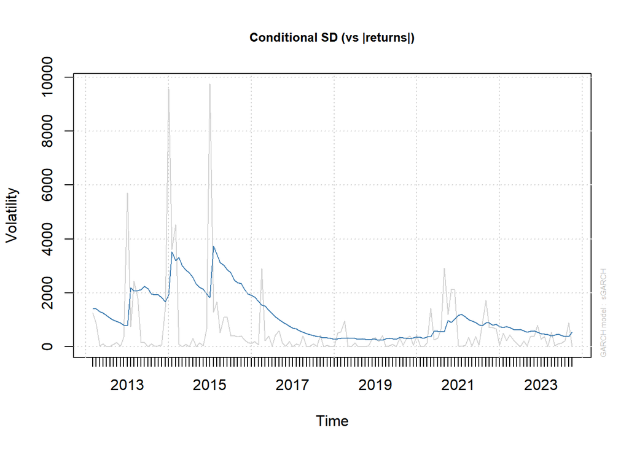

```r
# Gráfico da variância ou desvio padrão condicional
plot(ajuste_garch, which = 3)
```

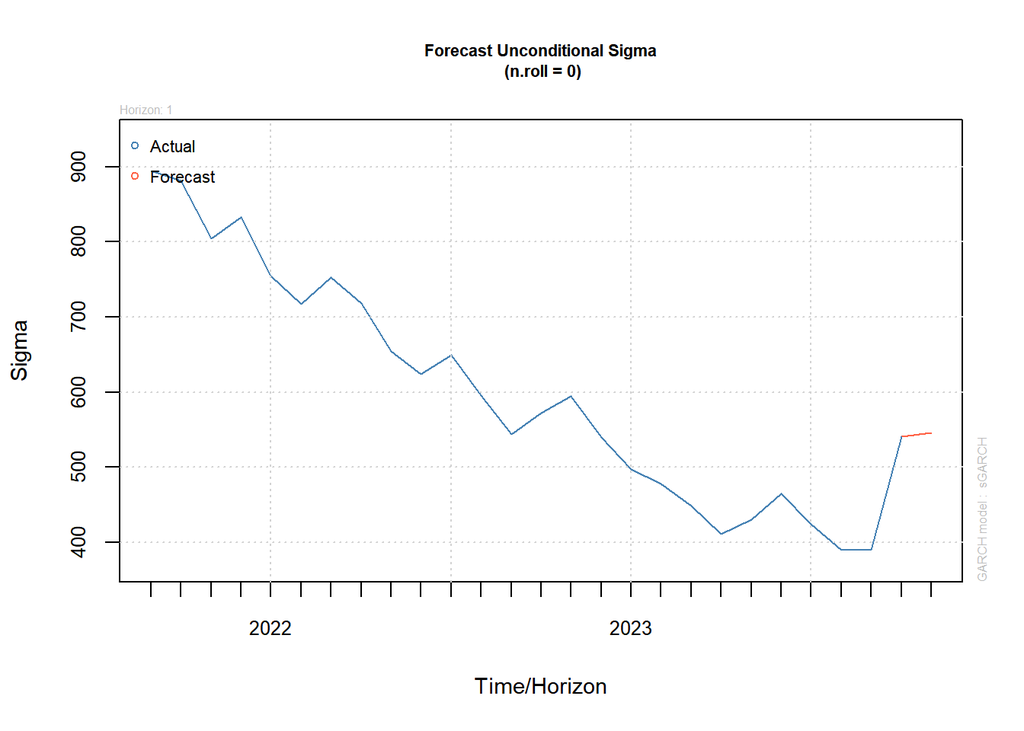

```r
# Realiza o forecast

forecast_garch <- ugarchforecast(ajuste_garch, n.ahead = 1)

plot(forecast_garch, which =3) # Forecast da variância
```

Para a previsão da série observa-se uma previsão de aumento da variância em um período a frente.

# 3 Conclusões

A série temporal do rendimento real médio mensal estudada oferece $\textit{insights}$ valiosos sobre a economia do país e as condições de vida da população. Ela reflete a dinâmica do mercado de trabalho brasileiro e suas flutuações ao longo do tempo.

A análise revelou a presença de sazonalidade na série temporal. Esta sazonalidade é do tipo multiplicativa e está relacionada a variações nos rendimentos ao longo do ano, com destaque para os meses de dezembro a fevereiro, nos quais as amplitudes de renda são mais evidentes.

A aplicação da metodologia X11 do Census Bureau dos Estados Unidos permitiu a dessazonalização da série, isolando a tendência e os componentes de erro. Isso nos possibilitou analisar a série de forma mais precisa, identificando padrões e correlações sem a influência das variações sazonais.

O modelo ARMA(2,2) foi identificado como o mais apropriado para modelar a série temporal, proporcionando uma base sólida para previsões futuras. A escolha foi fundamentada em critérios estatísticos robustos.

E como pôde ser notado há uma previsão de queda do rendimento real médio nos próximos meses, isto é, nos últimos meses de 2023 e nos primeiros meses de 2024, colocando fim a um período de crescimento da renda média desde 2022.

# 4 Referências

FIGUEIREDO, Adriano Marcos Rodrigues. Séries Temporais: decomposição clássica e a abordagem X11. Campo Grande-MS,Brasil: RStudio/Rpubs, 2019. Disponível em http://rpubs.com/amrofi/decompose_x11_varejoms.

HYNDMAN, Rob. (2018). fpp2: Data for “Forecasting: Principles and Practice” (2nd Edition). R package version 2.3. Disponível em: https://CRAN.R-project.org/package=fpp2.

Luiz Eduardo S. Gomes, Jessyka A. P. Goltara (2022). ipeadatar: API Wrapper for ‘Ipeadata’. R package version 0.1.6. URL: [https://CRAN.R-project.org/package=ipeadatar](https://cran.r-project.org/package=ipeadatar).

SAX C.; EDDELBUETTEL, D. (2018). “Seasonal Adjustment by X-13ARIMA-SEATS in R.” Journal of Statistical Software, 87(11), 1-17. doi: 10.18637/jss.v087.i11 (URL: https://doi.org/10.18637/jss.v087.i11).

US BUREAU OF THE CENSUS (2013). X-13ARIMA-SEATS Reference Manual Accessible HTML Output Version. Staff Statistical Research Division, US Bureau of the Census, disponível em: http://www.census.gov/ts/x13as/docX13ASHTML.pdf.